# Part 7 Robustness checks

Master thesis Section 3.5.3 (robustness design) and Section 4.4 / Table 11

Author

Lara Mazzarelli

## Role in the pipeline

| **Thesis section** | 3.5.3 (robustness design), Section 4.4 / Table 11 |
| --- | --- |
| **Previous file** | `06_regressions.qmd` |

## Setup and helper functions

The helper functions are copied from Part 6, so that this file runs on its own.

```r
source("00_config.R")
library(data.table)
library(fixest)
library(ggplot2)
library(countrycode)

d <- readRDS(file.path(path, "analysis_sample.rds"))
d <- setalloccol(d)   # allows adding columns by reference after readRDS
d[, sic2 := as.factor(sic2)]
if (!exists("cats")) cats <- c("d0_same4", "d1_same3", "d2_same2", "d3_same_division", "d4_diff_division")

c(firm_years = nrow(d), firms = uniqueN(d$gvkey))   # 461,882 and 43,407
```

```
firm_years      firms
    461882      43407
```

```r
# winsorisation as in Part 3 (default 1% / 99%)
wins <- function(x, p = 0.01) {
  q <- quantile(x, c(p, 1 - p), na.rm = TRUE)
  pmin(pmax(x, q[1]), q[2])
}

# Does coefficient a differ from coefficient b?
diff_test <- function(m, a, b) {
  v   <- vcov(m)
  est <- coef(m)[[a]] - coef(m)[[b]]
  se  <- sqrt(v[a, a] + v[b, b] - 2 * v[a, b])
  c(est = est, se = se, t = est / se, p = 2 * pnorm(-abs(est / se)))
}

# Any linear combination of coefficients
lin_test <- function(m, k, cv) {
  b <- coef(m); V <- vcov(m)
  est <- sum(cv * b[k])
  se  <- sqrt(as.numeric(t(cv) %*% V[k, k] %*% cv))
  c(est = est, se = se, t = est / se, p = 2 * pnorm(-abs(est / se)))
}

joint_p <- function(m, pattern = "^log1p\\(d") {
  wald(m, keep = pattern, print = FALSE)$p
}

omnibus_p <- function(m, pattern = "^log1p\\(d") {
  nm <- grep(pattern, names(coef(m)), value = TRUE)
  stopifnot(length(nm) == 5)
  R <- matrix(0, nrow = 4, ncol = 5)
  for (i in 1:4) { R[i, i] <- 1; R[i, i + 1] <- -1 }
  rb   <- R %*% coef(m)[nm]
  stat <- as.numeric(t(rb) %*% solve(R %*% vcov(m)[nm, nm] %*% t(R)) %*% rb)
  pchisq(stat, df = 4, lower.tail = FALSE)
}

controls <- "ln_at_usd + roa_w + leverage_w + growth_l1_w"
fe_main  <- "gvkey + sic2^fyear + country^fyear"

est <- function(rhs, fe = fe_main, y = "growth_f3_w", data = d, ctrl = controls) {
  rhs_all <- if (is.null(ctrl)) rhs else paste(rhs, "+", ctrl)
  feols(as.formula(paste0(y, " ~ ", rhs_all, " | ", fe)),
        data = data, cluster = ~gvkey)
}

rhs_h1   <- "log1p(n_rel_3y) + log1p(n_unrel_3y)"
rhs_dist <- function(suffix) paste0("log1p(", cats, suffix, ")", collapse = " + ")
rhs_h2   <- rhs_dist("_3y")
rhs_h4   <- paste0(c(rbind(paste0("log1p(", cats, "_eq_3y)"),
                           paste0("log1p(", cats, "_ne_3y)"))), collapse = " + ")

# H2: decline D3 to D4 and rise D0 to D3 (as in Part 6)
k_h4       <- c("log1p(d3_same_division_eq_3y)", "log1p(d4_diff_division_eq_3y)",
                "log1p(d3_same_division_ne_3y)", "log1p(d4_diff_division_ne_3y)")
k_h4_close <- c("log1p(d3_same_division_eq_3y)", "log1p(d0_same4_eq_3y)",
                "log1p(d3_same_division_ne_3y)", "log1p(d0_same4_ne_3y)")

rhs_h3 <- paste("log1p(n_rel_eq_3y) + log1p(n_rel_ne_3y)",
                "log1p(n_unrel_eq_3y) + log1p(n_unrel_ne_3y)", sep = " + ")
k_h3 <- c("log1p(n_rel_eq_3y)", "log1p(n_unrel_eq_3y)",
          "log1p(n_rel_ne_3y)", "log1p(n_unrel_ne_3y)")

# p-value of A1 (related vs. unrelated) for any model whose first two coefficients are RA and UA
h1_p <- function(m) {
  nm <- names(coef(m))[1:2]
  diff_test(m, nm[1], nm[2])[["p"]]
}

# One-row table from a test result
tidy <- function(label, x) data.table(test = label, est = x[["est"]], se = x[["se"]],
                                      t = x[["t"]], p = x[["p"]])

# Readable labels for the tables
dict <- c(growth_f3_w                  = "Revenue growth t to t+3",
          growth_f1_w                  = "Revenue growth t to t+1",
          "log1p(n_rel_3y)"            = "Related alliances (D0-D3)",
          "log1p(n_unrel_3y)"          = "Unrelated alliances (D4)",
          "log1p(d0_same4_3y)"         = "D0 same 4-digit",
          "log1p(d1_same3_3y)"         = "D1 same 3-digit",
          "log1p(d2_same2_3y)"         = "D2 same 2-digit",
          "log1p(d3_same_division_3y)" = "D3 same division",
          "log1p(d4_diff_division_3y)" = "D4 different division",
          "log1p(d0_same4)"            = "D0 same 4-digit (year t)",
          "log1p(d1_same3)"            = "D1 same 3-digit (year t)",
          "log1p(d2_same2)"            = "D2 same 2-digit (year t)",
          "log1p(d3_same_division)"    = "D3 same division (year t)",
          "log1p(d4_diff_division)"    = "D4 different division (year t)",
          "log1p(n_rel_eq_3y)"         = "Related, equity-based",
          "log1p(n_rel_ne_3y)"         = "Related, non-equity",
          "log1p(n_unrel_eq_3y)"       = "Unrelated, equity-based",
          "log1p(n_unrel_ne_3y)"       = "Unrelated, non-equity",
          ln_at_usd                    = "Size (ln assets, USD)",
          roa_w                        = "ROA",
          leverage_w                   = "Leverage",
          growth_l1_w                  = "Past growth",
          gvkey                        = "Firm",
          "sic2^fyear"                 = "Industry x Year",
          "country^fyear"              = "Country x Year")
```

## Table 11 checks: fixed effects, growth horizon, window, sample

| Check | What is varied | Model |
| --- | --- | --- |
| **R1** | without country x year FE | `m*_r1` |
| **R2** | without industry x year FE | `m2_r2` |
| **R3** | without firm FE | `m*_r3` |
| **R4** | without control variables | `m*_nc` |
| **R6** | one-year growth horizon | `m2_r4` |
| **R7** | alliance window: year t only, 2, 4, 5 years | `m2_r5_*` |
| **R9** | exclude 2009-2015 (SDC coverage gap) | `m*_r6` |
| design | linear counts, any-alliance indicator, cut D2/D3 (all A1), USD 20m floor (H1) | `m1_lin`, `m1_dum`, `m1_c2`, `m2_f20` |
| R19 (not in Table 11) | two-way clustering: firm and year (vs. firm only) | `m2_tw` |
| R20 (not in Table 11) | quadratic-in-distance functional form (vs. five distance categories) | `m2_quad` |

Each check changes one thing relative to the main specification. R5 and R8 are in Panel B below; R10 to R18 are in Panels C to E and Exit.

```r
# Main specification models, used as the comparison point for every check below
m1 <- est(rhs_h1)
m2 <- est(rhs_h2)
m3 <- est(rhs_h3)
m4 <- est(rhs_h4)

# R1-R3: fixed-effect structure
fe_r1 <- "gvkey + sic2^fyear"
fe_r2 <- "gvkey + country^fyear"
fe_r3 <- "sic2^fyear + country^fyear"

m1_r1 <- est(rhs_h1, fe_r1); m2_r1 <- est(rhs_h2, fe_r1); m3_r1 <- est(rhs_h3, fe_r1)
m2_r2 <- est(rhs_h2, fe_r2)
m1_r3 <- est(rhs_h1, fe_r3); m2_r3 <- est(rhs_h2, fe_r3)

# R4: one-year growth horizon (winsorised within the analysis sample)
m2_r4 <- est(rhs_h2, y = "growth_f1_w")

# R5: alliance window
m2_r5_t <- est(rhs_dist(""))      # alliances in year t only
m2_r5_2 <- est(rhs_dist("_w2"))
m2_r5_4 <- est(rhs_dist("_w4"))
m2_r5_5 <- est(rhs_dist("_w5"))

# R6: exclude the SDC coverage gap 2009-2015
d_gap <- d[!(fyear %in% 2009:2015)]
m2_r6 <- est(rhs_h2, data = d_gap)
m3_r6 <- est(rhs_h3, data = d_gap)
m4_r1 <- est(rhs_h4, fe_r1)          # H2 under R1
m4_r3 <- est(rhs_h4, fe_r3)          # H2 under R3 (across firms)
m4_r6 <- est(rhs_h4, data = d_gap)   # H2 under R6

# Design choices
m1_lin <- est("n_rel_3y + n_unrel_3y")                         # linear counts

d[, `:=`(any_rel   = as.integer(n_rel_3y > 0),                 # any-alliance indicator
         any_unrel = as.integer(n_unrel_3y > 0))]
m1_dum <- est("any_rel + any_unrel")

d[, `:=`(n_rel_c2   = d0_same4_3y + d1_same3_3y + d2_same2_3y,   # cut between D2 and D3
         n_unrel_c2 = d3_same_division_3y + d4_diff_division_3y)]
m1_c2 <- est("log1p(n_rel_c2) + log1p(n_unrel_c2)")

m2_f20 <- est(rhs_h2, data = d[revt_usd_lag >= 20])            # USD 20 million revenue floor

# Numbers needed for thesis section 3.3.2
round(diff_test(m1_c2, "log1p(n_rel_c2)", "log1p(n_unrel_c2)"), 4)   # est = X (cut D2/D3)
```

```
    est      se       t       p
-0.0011  0.0029 -0.4025  0.6873
```

```r
round(coef(m2_r5_5), 4)                                               # D4 coefficient at 5 years = Y
```

```
        log1p(d0_same4_w5)         log1p(d1_same3_w5)
                   -0.0052                    -0.0055
        log1p(d2_same2_w5) log1p(d3_same_division_w5)
                    0.0008                     0.0003
log1p(d4_diff_division_w5)                  ln_at_usd
                   -0.0078                    -0.0884
                     roa_w                 leverage_w
                   -0.0074                    -0.1023
               growth_l1_w
                   -0.0090
```

```r
# R4: without control variables
m1_nc <- est(rhs_h1, ctrl = NULL)
m2_nc <- est(rhs_h2, ctrl = NULL)
m3_nc <- est(rhs_h3, ctrl = NULL)
m4_nc <- est(rhs_h4, ctrl = NULL)

# tests, same as in the main models (A1, H1, A2, H2)
round(diff_test(m1_nc, "log1p(n_rel_3y)", "log1p(n_unrel_3y)"), 4)
```

```
   est     se      t      p
0.0044 0.0028 1.5609 0.1185
```

```r
c(joint_p = joint_p(m2_nc), omnibus_p = omnibus_p(m2_nc))
```

```
     joint_p    omnibus_p
3.166968e-30 9.005481e-04
```

```r
round(lin_test(m3_nc, k_h3, c(1, -1, -1, 1)), 4)
```

```
    est      se       t       p
-0.0020  0.0055 -0.3546  0.7229
```

```r
round(lin_test(m4_nc, k_h4, c(1, -1, -1, 1)), 4)
```

```
    est      se       t       p
-0.0073  0.0065 -1.1259  0.2602
```

```r
round(lin_test(m4_nc, k_h4_close, c(1, -1, -1, 1)), 4)
```

```
    est      se       t       p
-0.0086  0.0080 -1.0828  0.2789
```

```r
# nine-column check for the table
tab_nine_col <- etable(m2_nc, m2, m4_nc, m4, m1_nc, m1, m3_nc, m3, dict = dict,
       headers = c("H1 no ctrl", "H1", "H2 no ctrl", "H2", "B1 no ctrl", "B1", "B2 no ctrl", "B2"),
       digits = 4, fitstat = ~ n + r2 + wr2, tex = FALSE)
knitr::kable(tab_nine_col)
```

|  | m2_nc | m2 | m4_nc | m4 | m1_nc | m1 | m3_nc | m3 |
| --- | --- | --- | --- | --- | --- | --- | --- | --- |
|  | H1 no ctrl | H1 | H2 no ctrl | H2 | B1 no ctrl | B1 | B2 no ctrl | B2 |
| Dependent Var.: | Revenue growth t to t+3 | Revenue growth t to t+3 | Revenue growth t to t+3 | Revenue growth t to t+3 | Revenue growth t to t+3 | Revenue growth t to t+3 | Revenue growth t to t+3 | Revenue growth t to t+3 |
| D0 same 4-digit | -0.0110** (0.0034) | -0.0064* (0.0033) |  |  |  |  |  |  |
| D1 same 3-digit | -0.0138*** (0.0037) | -0.0040 (0.0034) |  |  |  |  |  |  |
| D2 same 2-digit | -0.0062* (0.0031) | -0.0012 (0.0030) |  |  |  |  |  |  |
| D3 same division | -0.0041. (0.0025) | 0.0014 (0.0024) |  |  |  |  |  |  |
| D4 different division | -0.0170*** (0.0019) | -0.0042* (0.0018) |  |  |  |  |  |  |
| Size (ln assets, USD) |  | -0.0886*** (0.0012) |  | -0.0886*** (0.0012) |  | -0.0886*** (0.0012) |  | -0.0886*** (0.0012) |
| ROA |  | -0.0072 (0.0051) |  | -0.0072 (0.0051) |  | -0.0072 (0.0051) |  | -0.0072 (0.0051) |
| Leverage |  | -0.1024*** (0.0039) |  | -0.1024*** (0.0039) |  | -0.1024*** (0.0039) |  | -0.1024*** (0.0039) |
| Past growth |  | -0.0089*** (0.0012) |  | -0.0089*** (0.0012) |  | -0.0089*** (0.0012) |  | -0.0089*** (0.0012) |
| log1p(d0_same4_eq_3y) |  |  | -0.0050 (0.0052) | -0.0027 (0.0050) |  |  |  |  |
| log1p(d0_same4_ne_3y) |  |  | -0.0110** (0.0039) | -0.0070. (0.0037) |  |  |  |  |
| log1p(d1_same3_eq_3y) |  |  | -0.0118. (0.0063) | -0.0064 (0.0059) |  |  |  |  |
| log1p(d1_same3_ne_3y) |  |  | -0.0118** (0.0041) | -0.0023 (0.0038) |  |  |  |  |
| log1p(d2_same2_eq_3y) |  |  | -0.0067 (0.0047) | -0.0014 (0.0043) |  |  |  |  |
| log1p(d2_same2_ne_3y) |  |  | -0.0041 (0.0038) | -0.0005 (0.0038) |  |  |  |  |
| log1p(d3_same_division_eq_3y) |  |  | -0.0044 (0.0038) | 0.0029 (0.0038) |  |  |  |  |
| log1p(d3_same_division_ne_3y) |  |  | -0.0018 (0.0029) | 0.0014 (0.0028) |  |  |  |  |
| log1p(d4_diff_division_eq_3y) |  |  | -0.0118*** (0.0030) | -0.0014 (0.0029) |  |  |  |  |
| log1p(d4_diff_division_ne_3y) |  |  | -0.0165*** (0.0021) | -0.0051* (0.0021) |  |  |  |  |
| Related alliances (D0-D3) |  |  |  |  | -0.0126*** (0.0018) | -0.0033. (0.0017) |  |  |
| Unrelated alliances (D4) |  |  |  |  | -0.0170*** (0.0019) | -0.0042* (0.0019) |  |  |
| Related, equity-based |  |  |  |  |  |  | -0.0086** (0.0027) | -0.0017 (0.0026) |
| Related, non-equity |  |  |  |  |  |  | -0.0112*** (0.0021) | -0.0031 (0.0020) |
| Unrelated, equity-based |  |  |  |  |  |  | -0.0117*** (0.0030) | -0.0012 (0.0029) |
| Unrelated, non-equity |  |  |  |  |  |  | -0.0162*** (0.0021) | -0.0050* (0.0021) |
| Fixed-Effects: | ———————– | ———————– | ———————– | ———————– | ———————– | ———————– | ———————– | ———————– |
| Firm | Yes | Yes | Yes | Yes | Yes | Yes | Yes | Yes |
| Industry x Year | Yes | Yes | Yes | Yes | Yes | Yes | Yes | Yes |
| Country x Year | Yes | Yes | Yes | Yes | Yes | Yes | Yes | Yes |
| _____________________________ | _______________________ | _______________________ | _______________________ | _______________________ | _______________________ | _______________________ | _______________________ | _______________________ |
| S.E.: Clustered | by: Firm | by: Firm | by: Firm | by: Firm | by: Firm | by: Firm | by: Firm | by: Firm |
| Observations | 457,325 | 457,325 | 457,325 | 457,325 | 457,325 | 457,325 | 457,325 | 457,325 |
| R2 | 0.39374 | 0.44288 | 0.39372 | 0.44288 | 0.39375 | 0.44287 | 0.39373 | 0.44287 |
| Within R2 | 0.00083 | 0.08182 | 0.00080 | 0.08183 | 0.00085 | 0.08181 | 0.00082 | 0.08181 |

```r
# direction of the R3 results (across firms)
m1_r3 <- est(rhs_h1, fe = "sic2^fyear + country^fyear")
m3_r3 <- est(rhs_h3, fe = "sic2^fyear + country^fyear")
round(diff_test(m1_r3, "log1p(n_rel_3y)", "log1p(n_unrel_3y)"), 4)
```

```
   est     se      t      p
0.0118 0.0027 4.3939 0.0000
```

```r
round(lin_test(m3_r3, k_h3, c(1, -1, -1, 1)), 4)
```

```
    est      se       t       p
-0.0128  0.0054 -2.3817  0.0172
```

```r
round(lin_test(m4_r3, k_h4, c(1, -1, -1, 1)), 4)   # H2 across firms
```

```
    est      se       t       p
-0.0008  0.0064 -0.1179  0.9061
```

```r
m2_r3 <- est(rhs_h2, fe = "sic2^fyear + country^fyear")
round(coef(m2_r3)[grep("^log1p\\(d", names(coef(m2_r3)))], 4)
```

```
        log1p(d0_same4_3y)         log1p(d1_same3_3y)
                    0.0069                     0.0112
        log1p(d2_same2_3y) log1p(d3_same_division_3y)
                   -0.0060                     0.0003
log1p(d4_diff_division_3y)
                   -0.0039
```

```r
round(diff_test(m2_r3, "log1p(d3_same_division_3y)", "log1p(d0_same4_3y)"), 4)
```

```
    est      se       t       p
-0.0066  0.0039 -1.7157  0.0862
```

```r
round(diff_test(m2_r3, "log1p(d3_same_division_3y)", "log1p(d4_diff_division_3y)"), 4)
```

```
   est     se      t      p
0.0042 0.0033 1.3040 0.1922
```

### R19: two-way clustering (firm and year)

Standard errors are clustered by firm throughout. Firm-year observations within the same year can also be correlated (common macro or industry-wide shocks that the industry x year and country x year fixed effects do not fully absorb), so this check clusters two-way by firm and by fiscal year instead.

```r
m2_tw <- feols(as.formula(paste0("growth_f3_w ~ ", rhs_h2, " + ", controls, " | ", fe_main)),
               data = d, cluster = ~gvkey + fyear)

tab_r19 <- etable(m2, m2_tw, dict = dict, digits = 4, fitstat = ~ n + r2 + wr2,
       headers = c("Main (cluster: firm)", "R19 (cluster: firm + year)"), tex = FALSE)
knitr::kable(tab_r19)
```

|  | m2 | m2_tw |
| --- | --- | --- |
|  | Main (cluster: firm) | R19 (cluster: firm + year) |
| Dependent Var.: | Revenue growth t to t+3 | Revenue growth t to t+3 |
| D0 same 4-digit | -0.0064* (0.0033) | -0.0064. (0.0032) |
| D1 same 3-digit | -0.0040 (0.0034) | -0.0040 (0.0036) |
| D2 same 2-digit | -0.0012 (0.0030) | -0.0012 (0.0029) |
| D3 same division | 0.0014 (0.0024) | 0.0014 (0.0026) |
| D4 different division | -0.0042* (0.0018) | -0.0042* (0.0020) |
| Size (ln assets, USD) | -0.0886*** (0.0012) | -0.0886*** (0.0036) |
| ROA | -0.0072 (0.0051) | -0.0072 (0.0153) |
| Leverage | -0.1024*** (0.0039) | -0.1024*** (0.0051) |
| Past growth | -0.0089*** (0.0012) | -0.0089** (0.0027) |
| Fixed-Effects: | ———————– | ———————– |
| Firm | Yes | Yes |
| Industry x Year | Yes | Yes |
| Country x Year | Yes | Yes |
| _____________________ | _______________________ | _______________________ |
| S.E.: Clustered | by: Firm | by: Firm & fyear |
| Observations | 457,325 | 457,325 |
| R2 | 0.44288 | 0.44288 |
| Within R2 | 0.08182 | 0.08182 |

```r
round(c(main_omnibus_p = omnibus_p(m2), tw_omnibus_p = omnibus_p(m2_tw),
        main_joint_p = joint_p(m2), tw_joint_p = joint_p(m2_tw)), 4)
```

```
main_omnibus_p   tw_omnibus_p   main_joint_p     tw_joint_p
        0.2578         0.2702         0.0231         0.0691
```

### R20: quadratic-in-distance functional form

The main specification (`m2`) imposes no shape on the five distance categories, so an inverted U is not assumed. This check instead collapses the five categories into one continuous distance score per firm-year – the alliance-count-weighted mean of the category index 0 (D0) to 4 (D4) – and tests a linear and a squared term on it. Firm-years with no alliance in the window get a distance of 0, consistent with how `log1p(N)` already treats “no alliance” as the reference case. An inverted U-shape implies a positive linear term and a negative squared term, jointly significant.

```r
d[, n_all_3y := d0_same4_3y + d1_same3_3y + d2_same2_3y + d3_same_division_3y + d4_diff_division_3y]
d[, avg_dist := fifelse(n_all_3y == 0, 0,
                        (0 * d0_same4_3y + 1 * d1_same3_3y + 2 * d2_same2_3y +
                           3 * d3_same_division_3y + 4 * d4_diff_division_3y) / n_all_3y)]
d[, avg_dist_sq := avg_dist^2]

m2_quad <- est("avg_dist + avg_dist_sq")
tab_m2_quad <- etable(m2_quad, dict = dict, digits = 4, fitstat = ~ n + r2 + wr2, tex = FALSE)
knitr::kable(tab_m2_quad)
```

|  | m2_quad |
| --- | --- |
| Dependent Var.: | Revenue growth t to t+3 |
| avg_dist | -0.0033 (0.0020) |
| avg_dist_sq | 0.0005 (0.0005) |
| Size (ln assets, USD) | -0.0886*** (0.0012) |
| ROA | -0.0072 (0.0051) |
| Leverage | -0.1024*** (0.0039) |
| Past growth | -0.0089*** (0.0012) |
| Fixed-Effects: | ———————– |
| Firm | Yes |
| Industry x Year | Yes |
| Country x Year | Yes |
| _____________________ | _______________________ |
| S.E.: Clustered | by: Firm |
| Observations | 457,325 |
| R2 | 0.44287 |
| Within R2 | 0.08181 |

```r
wald(m2_quad, keep = "avg_dist", print = FALSE)$p   # joint test of avg_dist and avg_dist_sq
```

```
[1] 0.001351448
```

### Design-choices overview (backs the Section 4.4 narrative)

Main p = p-value of the main specification; Alt. p = p-value of the alternative. For the H1 rows the joint test is reported as in the thesis; the omnibus test (the actual basis for H1) is added in the last two columns. The rows for the related/unrelated comparison belong to additional analysis B1. H2 is covered across the same design choices in the overview table below (`table9`).

```r
row7 <- function(group, choice, alternative, stat, m_main, m_alt) {
  if (stat == "Joint test (H1)") {
    data.table(group, choice, alternative, statistic = stat,
               main_p = joint_p(m_main), alt_p = joint_p(m_alt),
               main_omnibus_p = omnibus_p(m_main), alt_omnibus_p = omnibus_p(m_alt))
  } else {
    data.table(group, choice, alternative, statistic = stat,
               main_p = h1_p(m_main), alt_p = h1_p(m_alt),
               main_omnibus_p = NA_real_, alt_omnibus_p = NA_real_)
  }
}
s_h1 <- "Joint test (H1)"; s_a1 <- "RA - UA (A1)"

table7 <- rbindlist(list(
  row7("Model",       "Country x year fixed effects", "R1: without them",           s_h1, m2, m2_r1),
  row7("Model",       "Industry x year fixed effects", "R2: without them",          s_h1, m2, m2_r2),
  row7("Model",       "Firm fixed effects",           "R3: without them",           s_h1, m2, m2_r3),
  row7("Model", "Control variables", "R4: without them", s_h1, m2, m2_nc),
  row7("Measurement", "Growth horizon: three years",  "R6: one-year growth",        s_h1, m2, m2_r4),
  row7("Measurement", "Alliance window: three years", "R7: year t only",            s_h1, m2, m2_r5_t),
  row7("Measurement", "Alliance window: three years", "R7: two years",              s_h1, m2, m2_r5_2),
  row7("Measurement", "Alliance window: three years", "R7: four years",             s_h1, m2, m2_r5_4),
  row7("Measurement", "Alliance window: three years", "R7: five years",             s_h1, m2, m2_r5_5),
  row7("Measurement", "Alliance counts: ln(1 + N)",   "Linear counts",              s_a1, m1, m1_lin),
  row7("Measurement", "Alliance counts: ln(1 + N)",   "Indicator for any alliance", s_a1, m1, m1_dum),
  row7("Measurement", "Relatedness cut: D3 | D4",     "Cut between D2 and D3",      s_a1, m1, m1_c2),
  row7("Sample",      "SDC coverage gap 2009-2015",   "R9: exclude these years",    s_h1, m2, m2_r6),
  row7("Sample",      "Revenue floor: USD 10 million", "USD 20 million",            s_h1, m2, m2_f20)))

knitr::kable(table7, digits = 4)
```

| group | choice | alternative | statistic | main_p | alt_p | main_omnibus_p | alt_omnibus_p |
| --- | --- | --- | --- | --- | --- | --- | --- |
| Model | Country x year fixed effects | R1: without them | Joint test (H1) | 0.0231 | 0.1285 | 0.2578 | 0.2583 |
| Model | Industry x year fixed effects | R2: without them | Joint test (H1) | 0.0231 | 0.0119 | 0.2578 | 0.2843 |
| Model | Firm fixed effects | R3: without them | Joint test (H1) | 0.0231 | 0.0000 | 0.2578 | 0.0000 |
| Model | Control variables | R4: without them | Joint test (H1) | 0.0231 | 0.0000 | 0.2578 | 0.0009 |
| Measurement | Growth horizon: three years | R6: one-year growth | Joint test (H1) | 0.0231 | 0.0005 | 0.2578 | 0.3778 |
| Measurement | Alliance window: three years | R7: year t only | Joint test (H1) | 0.0231 | 0.7469 | 0.2578 | 0.7011 |
| Measurement | Alliance window: three years | R7: two years | Joint test (H1) | 0.0231 | 0.2305 | 0.2578 | 0.3943 |
| Measurement | Alliance window: three years | R7: four years | Joint test (H1) | 0.0231 | 0.0009 | 0.2578 | 0.0897 |
| Measurement | Alliance window: three years | R7: five years | Joint test (H1) | 0.0231 | 0.0001 | 0.2578 | 0.0490 |
| Measurement | Alliance counts: ln(1 + N) | Linear counts | RA - UA (A1) | 0.7488 | 0.9756 | NA | NA |
| Measurement | Alliance counts: ln(1 + N) | Indicator for any alliance | RA - UA (A1) | 0.7488 | 0.3197 | NA | NA |
| Measurement | Relatedness cut: D3 \| D4 | Cut between D2 and D3 | RA - UA (A1) | 0.7488 | 0.6873 | NA | NA |
| Sample | SDC coverage gap 2009-2015 | R9: exclude these years | Joint test (H1) | 0.0231 | 0.0054 | 0.2578 | 0.2013 |
| Sample | Revenue floor: USD 10 million | USD 20 million | Joint test (H1) | 0.0231 | 0.1003 | 0.2578 | 0.5385 |

```r
fwrite(table7, file.path(path, "table7_robustness_overview.csv"))

#| label: robustness-all
# One row per design choice: p-values of the primary test of each hypothesis
# (H1 = omnibus test of m2; H2 = moderation test of m4 at the far end (D3 to D4)
#  and at the close end (D0 to D3); B1 and B2 = additional analyses)
check_p <- function(label, fe = fe_main, y = "growth_f3_w", data = d, ctrl = controls) {
  m1 <- est(rhs_h1, fe, y, data, ctrl)
  m2 <- est(rhs_h2, fe, y, data, ctrl)
  m3 <- est(rhs_h3, fe, y, data, ctrl)
  m4 <- est(rhs_h4, fe, y, data, ctrl)
  data.table(check = label,
             H1_omnibus = omnibus_p(m2),
             H1_joint   = joint_p(m2),
             H2         = lin_test(m4, k_h4,       c(1, -1, -1, 1))[["p"]],
             H2_close   = lin_test(m4, k_h4_close, c(1, -1, -1, 1))[["p"]],
             B1         = diff_test(m1, "log1p(n_rel_3y)", "log1p(n_unrel_3y)")[["p"]],
             B2         = lin_test(m3, k_h3, c(1, -1, -1, 1))[["p"]])
}

res <- rbindlist(list(
  check_p("Main specification"),
  check_p("R1: without country x year FE", fe = "gvkey + sic2^fyear"),
  check_p("R2: without industry x year FE", fe = "gvkey + country^fyear"),
  check_p("R3: without firm FE", fe = "sic2^fyear + country^fyear"),
  check_p("R4: without controls", ctrl = NULL),
  check_p("R6: one-year growth", y = "growth_f1_w"),
  check_p("R9: excluding 2009-2015", data = d[!(fyear %in% 2009:2015)]),
  check_p("USD 20 million floor", data = d[revt_usd_lag >= 20])
))
num <- setdiff(names(res), "check")
res[, (num) := lapply(.SD, round, 4), .SDcols = num]
knitr::kable(res)
```

| check | H1_omnibus | H1_joint | H2 | H2_close | B1 | B2 |
| --- | --- | --- | --- | --- | --- | --- |
| Main specification | 0.2578 | 0.0231 | 0.7305 | 0.7166 | 0.7488 | 0.6485 |
| R1: without country x year FE | 0.2583 | 0.1285 | 0.6038 | 0.5987 | 0.9991 | 0.5165 |
| R2: without industry x year FE | 0.2843 | 0.0119 | 0.4516 | 0.7633 | 0.9344 | 0.4060 |
| R3: without firm FE | 0.0000 | 0.0000 | 0.9061 | 0.2162 | 0.0000 | 0.0172 |
| R4: without controls | 0.0009 | 0.0000 | 0.2602 | 0.2789 | 0.1185 | 0.7229 |
| R6: one-year growth | 0.3778 | 0.0005 | 0.7007 | 0.8252 | 0.8391 | 0.7588 |
| R9: excluding 2009-2015 | 0.2013 | 0.0054 | 0.6353 | 0.6339 | 0.7697 | 0.9238 |
| USD 20 million floor | 0.5385 | 0.1003 | 0.8971 | 0.8999 | 0.9877 | 0.6170 |

```r
fwrite(res, file.path(path, "table9_all_hypotheses.csv"))
```

### Governance effects under R1 and R9

```r
knitr::kable(rbind(
  tidy("Main: H2 moderation",           lin_test(m4,    k_h4, c(1, -1, -1, 1))),
  tidy("R1: H2 moderation",             lin_test(m4_r1, k_h4, c(1, -1, -1, 1))),
  tidy("R9: H2 moderation",             lin_test(m4_r6, k_h4, c(1, -1, -1, 1))),
  tidy("Main: A2 moderation",           lin_test(m3,    k_h3, c(1, -1, -1, 1))),
  tidy("R1: A2 moderation",             lin_test(m3_r1, k_h3, c(1, -1, -1, 1))),
  tidy("R9: A2 moderation",             lin_test(m3_r6, k_h3, c(1, -1, -1, 1))),
  tidy("Main: equity main effect",      lin_test(m3,    k_h3, c(0.5, 0.5, -0.5, -0.5))),
  tidy("R1: equity main effect",        lin_test(m3_r1, k_h3, c(0.5, 0.5, -0.5, -0.5))),
  tidy("R9: equity main effect",        lin_test(m3_r6, k_h3, c(0.5, 0.5, -0.5, -0.5)))),
  digits = 4)
```

| test | est | se | t | p |
| --- | --- | --- | --- | --- |
| Main: H2 moderation | -0.0022 | 0.0063 | -0.3445 | 0.7305 |
| R1: H2 moderation | -0.0033 | 0.0064 | -0.5189 | 0.6038 |
| R9: H2 moderation | -0.0033 | 0.0070 | -0.4742 | 0.6353 |
| Main: A2 moderation | -0.0024 | 0.0053 | -0.4558 | 0.6485 |
| R1: A2 moderation | -0.0035 | 0.0053 | -0.6488 | 0.5165 |
| R9: A2 moderation | -0.0006 | 0.0059 | -0.0956 | 0.9238 |
| Main: equity main effect | 0.0026 | 0.0023 | 1.1274 | 0.2596 |
| R1: equity main effect | 0.0014 | 0.0023 | 0.6409 | 0.5216 |
| R9: equity main effect | 0.0035 | 0.0025 | 1.4145 | 0.1572 |

### Figure: distance effects across design choices

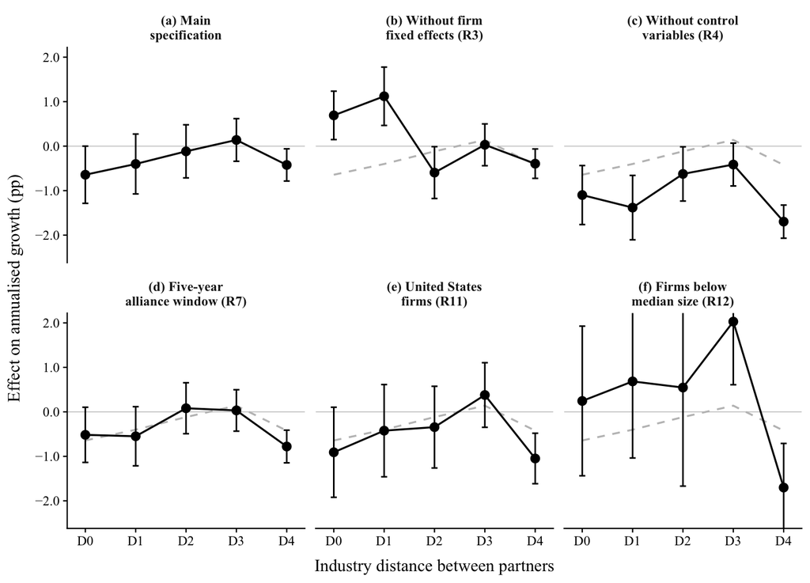

Figure 1

```r
fam <- "Times New Roman"

get_co <- function(m, spec) {
  x <- as.data.table(coeftable(m), keep.rownames = "term")[grepl("^log1p\\(d", term)]
  setnames(x, c("Estimate", "Std. Error"), c("est", "se"))
  x[, `:=`(est = 100 * est, se = 100 * se, spec = spec, x = 1:5)]      # percentage points
  x[, `:=`(lo = est - 1.96 * se, hi = est + 1.96 * se)]
}

m2_r11 <- est(rhs_h2, data = d[country == "USA"])
med_size_for_panels <- median(d$ln_at_usd, na.rm = TRUE)
m2_r12 <- est(rhs_h2, data = d[ln_at_usd <= med_size_for_panels])

lev <- c("(a) Main\nspecification",
         "(b) Without firm\nfixed effects (R3)",
         "(c) Without control\nvariables (R4)",
         "(d) Five-year\nalliance window (R7)",
         "(e) United States\nfirms (R11)",
         "(f) Firms below\nmedian size (R12)")
panel_dt <- rbind(get_co(m2,      lev[1]),
                  get_co(m2_r3,   lev[2]),
                  get_co(m2_nc,   lev[3]),
                  get_co(m2_r5_5, lev[4]),
                  get_co(m2_r11,  lev[5]),
                  get_co(m2_r12,  lev[6]))
panel_dt[, spec := factor(spec, levels = lev)]

# main specification as a grey dashed reference line in panels (b) to (d)
ref <- panel_dt[spec == lev[1], .(x, est_ref = est)]
dr  <- panel_dt[spec != lev[1]][ref, on = "x", nomatch = 0]

p_panels <- ggplot(panel_dt, aes(x = x, y = est)) +
  geom_hline(yintercept = 0, colour = "grey80", linewidth = 0.3) +
  geom_line(data = dr, aes(y = est_ref, group = spec), colour = "grey75",
            linewidth = 0.6, linetype = "dashed") +
  geom_line(colour = "black", linewidth = 0.6) +
  geom_errorbar(aes(ymin = lo, ymax = hi), width = 0.12, linewidth = 0.5, colour = "black") +
  geom_point(size = 2.4, colour = "black") +
  facet_wrap(~ spec, nrow = 2) +
  scale_x_continuous(breaks = 1:5, labels = paste0("D", 0:4), expand = expansion(add = 0.3)) +
  scale_y_continuous(breaks = seq(-2, 2, 1),
                     labels = function(x) sub("-", "\u2212", format(x, nsmall = 1))) +
  coord_cartesian(ylim = c(-2.4, 2.0)) +
  labs(x = "Industry distance between partners", y = "Effect on annualised growth (pp)") +
  theme_classic(base_size = 11, base_family = fam) +
  theme(strip.background = element_blank(),
        strip.text   = element_text(face = "bold", size = 9, hjust = 0.5),
        axis.text    = element_text(colour = "black", size = 9),
        axis.title   = element_text(colour = "black", size = 11.5),
        axis.title.x = element_text(margin = margin(t = 8)),
        axis.title.y = element_text(margin = margin(r = 8)),
        axis.line    = element_line(colour = "black", linewidth = 0.4),
        axis.ticks   = element_line(colour = "black", linewidth = 0.4),
        panel.spacing = unit(0.5, "lines"))
p_panels
ggsave(file.path(path, "fig_panels.png"), p_panels, width = 7.5, height = 5.4, dpi = 300)
```

## New tests (section 4.5.2)

**Single contrast for H1.** The omnibus test of H1 has four restrictions, so it has little power against one specific shape. The contrast compares the average of D1 to D3 with the average of D0 and D4. An inverted U-shape predicts a positive value. It is reported as supporting evidence; the omnibus test stays the basis of the H1 evaluation.

**Minimum detectable effect for H2.** 2.487 x the standard error of the H2 contrast (1.645 + 0.842), i.e. the smallest effect that a one-sided test at the 5% level detects with a power of 80%. It is reported in percentage points.

```r
w_c   <- c(-1/2, 1/3, 1/3, 1/3, -1/2)    # mean(D1-D3) - mean(D0, D4)
MDE_F <- 1.645 + 0.842

# one row of tests for one design; same columns as Table 11
check_new <- function(label, fe = fe_main, y = "growth_f3_w", data = d,
                      ctrl = controls, h2 = TRUE) {
  out <- data.table(check = label, H1_omnibus = NA_real_, H1_joint = NA_real_,
                    H1_contrast_est = NA_real_, H1_contrast_p = NA_real_,
                    H2_rise = NA_real_, H2_decline = NA_real_,
                    B1 = NA_real_, MDE_rise_pp = NA_real_, MDE_decline_pp = NA_real_)
  tryCatch({
    m2 <- est(rhs_h2, fe, y, data, ctrl)
    nm <- names(coef(m2))[1:5]
    ct <- lin_test(m2, nm, w_c)
    out[, `:=`(H1_omnibus = omnibus_p(m2), H1_joint = joint_p(m2),
               H1_contrast_est = ct[["est"]], H1_contrast_p = ct[["p"]])]
    if (h2) {
      m1 <- est(rhs_h1, fe, y, data, ctrl)
      m4 <- est(rhs_h4, fe, y, data, ctrl)
      rise    <- lin_test(m4, k_h4_close, c(1, -1, -1, 1))
      decline <- lin_test(m4, k_h4,       c(1, -1, -1, 1))
      out[, `:=`(H2_rise = rise[["p"]], H2_decline = decline[["p"]],
                 B1 = diff_test(m1, "log1p(n_rel_3y)", "log1p(n_unrel_3y)")[["p"]],
                 MDE_rise_pp = 100 * MDE_F * rise[["se"]],
                 MDE_decline_pp = 100 * MDE_F * decline[["se"]])]
    }
  }, error = function(e) message(label, ": ", conditionMessage(e)))
  out
}

res_list <- list(check_new("Main specification"))
```

## Panel B: timing and causality

**R8 Placebo.** The dependent variable is the annualised revenue growth from t-6 to t-3. It ends before the alliance window (t-2 to t) starts. If the distance categories are associated with growth before the alliances, the main result may reflect pre-existing growth. Past growth (t-1 to t) is left out of the controls because it lies after the outcome period. Size, ROA and leverage are measured in t, so R8 is also run without controls.

**Non-overlapping windows.** Only every third fiscal year, so that the three-year growth windows of a firm do not overlap. The result depends on which years are kept, therefore all three starting points are reported.

**Firm-specific linear trends (R5).** `gvkey[t_c]` adds a firm fixed effect and a linear time trend (centred year) for each firm.

```r
# Revenue in t+k (reporting currency) for every firm-year, with its currency
fp <- readRDS(file.path(path, "firmyear_panel.rds"))
rv <- fp[, .(gvkey, fyear, revt, curcd)]

add_rev <- function(dt, k, name) {
  x <- rv[, .(gvkey, fyear = fyear - as.integer(k), r = revt, cur = curcd)]
  cols <- c(name, paste0(name, "_cur"))
  setnames(x, c("r", "cur"), cols)
  dt[x, on = .(gvkey, fyear), (cols) := mget(paste0("i.", cols))]
  dt   # returned: always assign the result, e.g. d <- add_rev(d, ...)
}
# annualised growth between two revenue observations n years apart (same currency only)
ann <- function(r1, c1, r0, c0, n) fifelse(r1 > 0 & r0 > 0 & c1 == c0, (r1 / r0)^(1 / n) - 1, NA_real_)

d <- add_rev(d, -6, "r_m6")
d <- add_rev(d, -3, "r_m3")
d <- add_rev(d, 1,  "r_p1")
d <- add_rev(d, 3,  "r_p3")

d[, g_pre := wins(ann(r_m3, r_m3_cur, r_m6, r_m6_cur, 3))]   # t-6 to t-3
d[, g_alt := wins(ann(r_p3, r_p3_cur, r_p1, r_p1_cur, 2))]   # t+1 to t+3
d[, .(g_pre_available = mean(!is.na(g_pre)), g_alt_available = mean(!is.na(g_alt)))]
```

```
   g_pre_available g_alt_available
             <num>           <num>
1:       0.7360733       0.9968022
```

```r
ctrl_placebo <- "ln_at_usd + roa_w + leverage_w"
d[, t_c := as.numeric(fyear) - 2005]   # centred year for the firm-specific trends

res_list <- c(res_list, list(
  check_new("R8: placebo, growth t-6 to t-3", y = "g_pre", ctrl = ctrl_placebo, h2 = FALSE),
  check_new("R8: placebo, no controls",       y = "g_pre", ctrl = NULL,         h2 = FALSE),
  check_new("Non-overlapping, fyear mod 3 = 0", data = d[fyear %% 3L == 0L]),
  check_new("Non-overlapping, fyear mod 3 = 1", data = d[fyear %% 3L == 1L]),
  check_new("Non-overlapping, fyear mod 3 = 2", data = d[fyear %% 3L == 2L]),
  check_new("R5: firm-specific linear trends", fe = "gvkey[t_c] + sic2^fyear + country^fyear")))
```

## Panel C: measurement

**Winsorisation.** The main specification winsorises at 1% and 99% of the full panel (Part 3). Here growth is winsorised at 0.5%/99.5% and 5%/95% of the analysis sample, and not winsorised at all.

**Growth from t+1 to t+3.** Excludes the year t, in which the last alliance of the window can be formed.

**At most one alliance in the window.** Each firm-year then belongs to one distance category only, so the categories are not mixed.

**Cross-border alliances.** Industry distance and geographic distance between the partners may be correlated. The control is the number of alliances in t-2 to t whose partner is located in another country than the focal firm.

```r
# Partner country (SDC name) -> ISO3, same fixes as in Part 2
to_iso <- function(x) {
  fix <- c("Serbia and Montenegro" = "SRB", "Yugoslavia" = "SRB",
           "German Democratic Republic" = "DEU", "Netherlands Antilles" = "ANT",
           "Micronesia" = "FSM")
  out <- countrycode(x, "country.name", "iso3c", warn = FALSE)
  out[x %in% names(fix)] <- fix[x[x %in% names(fix)]]
  out
}

af <- readRDS(file.path(path, "alliances_focal.rds"))
nat <- unique(af$partner_nation)
nat_iso <- setNames(to_iso(nat), nat)
af[, `:=`(partner_iso = nat_iso[partner_nation], fyear = year)]

ctry <- unique(fp[, .(gvkey, fyear, country)])
af <- merge(af, ctry, by = c("gvkey", "fyear"))
af[, xb := as.integer(!is.na(partner_iso) & !is.na(country) & partner_iso != country)]
af[, .(alliances = .N, cross_border_share = round(mean(xb), 3))]
```

```
   alliances cross_border_share
       <int>              <num>
1:     96561              0.566
```

```r
xb_c <- af[, .(n_xb = sum(xb)), by = .(gvkey, fyear)]

# three-year window t-2 to t, same logic as for the other counts in Part 3
d[xb_c, on = .(gvkey, fyear), n_xb0 := i.n_xb]
for (l in 1:2) {
  src <- xb_c[, .(gvkey, fyear = fyear + l, n_xb)]
  nm_l <- paste0("n_xb", l)
  d[src, on = .(gvkey, fyear), (nm_l) := i.n_xb]
}
d[, n_xb_3y := fcoalesce(n_xb0, 0L) + fcoalesce(n_xb1, 0L) + fcoalesce(n_xb2, 0L)]
d[, c("n_xb0", "n_xb1", "n_xb2") := NULL]

# sanity check: cross-border alliances cannot exceed all alliances
d[, .(share_with_cross_border = mean(n_xb_3y > 0), violates = sum(n_xb_3y > n_alliances_3y))]
```

```
   share_with_cross_border violates
                     <num>    <int>
1:              0.06913021        0
```

```r
stopifnot("growth_f3" %in% names(d))   # raw (unwinsorised) growth from Part 3
d[, `:=`(g_w05 = wins(growth_f3, 0.005), g_w5 = wins(growth_f3, 0.05))]

res_list <- c(res_list, list(
  check_new("Winsorised 0.5% / 99.5%", y = "g_w05"),
  check_new("Winsorised 5% / 95%",     y = "g_w5"),
  check_new("Not winsorised",          y = "growth_f3"),
  check_new("Growth t+1 to t+3",       y = "g_alt"),
  check_new("At most one alliance in window", data = d[n_alliances_3y <= 1]),
  check_new("Control for cross-border alliances",
            ctrl = paste(controls, "+ log1p(n_xb_3y)"))))
```

## Panel D: sample

US and non-US firms, years until 2008 and from 2016 (before and after the reduced SDC coverage), and below- vs. above-median firm size.

```r
med_size <- median(d$ln_at_usd, na.rm = TRUE)

res_list <- c(res_list, list(
  check_new("US firms",              data = d[country == "USA"]),
  check_new("Non-US firms",          data = d[country != "USA"]),
  check_new("Until 2008",            data = d[fyear <= 2008]),
  check_new("From 2016",             data = d[fyear >= 2016]),
  check_new("Below-median size",     data = d[ln_at_usd <= med_size]),
  check_new("Above-median size",     data = d[ln_at_usd >  med_size])))
```

## Panel E: revenue floor

**No revenue floor (R10).** The main specification drops firm-years with revenue below USD 10m in t-1 (Section 3.1), the floor used to cut firms whose ratios are distorted by division by a very small base. Here that filter is skipped, so the sample includes firm-years below the floor that pass every other filter. Because the construction of the alliance counts, their 3-year windows, and the winsorisation happen on the full panel before any filtering (Part 3), the pipeline is rebuilt here from a fresh copy of `firmyear_panel.rds` rather than by filtering `d`.

```r
fp_raw <- readRDS(file.path(path, "firmyear_panel.rds"))

fp_raw[, fyear3 := fyear + 3L]
fp_raw[fp_raw, on = .(gvkey, fyear3 = fyear), `:=`(revt_f3 = i.revt, curcd_f3 = i.curcd)]
fp_raw[, growth_f3 := fifelse(revt > 0 & revt_f3 > 0 & curcd == curcd_f3,
                              (revt_f3 / revt)^(1/3) - 1, NA_real_)]
fp_raw[, `:=`(growth_f3_w = wins(growth_f3),
             growth_l1_w = wins(growth_l1),
             roa_w       = wins(roa),
             leverage_w  = wins(leverage))]

cats_r21 <- c("d0_same4", "d1_same3", "d2_same2", "d3_same_division", "d4_diff_division")
for (k in cats_r21) fp_raw[, (k) := get(paste0(k, "_eq")) + get(paste0(k, "_ne"))]
fp_raw[, `:=`(n_rel      = d0_same4 + d1_same3 + d2_same2 + d3_same_division,
             n_unrel    = d4_diff_division,
             n_rel_eq   = d0_same4_eq + d1_same3_eq + d2_same2_eq + d3_same_division_eq,
             n_rel_ne   = d0_same4_ne + d1_same3_ne + d2_same2_ne + d3_same_division_ne,
             n_unrel_eq = d4_diff_division_eq,
             n_unrel_ne = d4_diff_division_ne)]

setorder(fp_raw, gvkey, fyear)
cnt_r21 <- c("n_alliances", "n_jv", cats_r21, "n_rel", "n_unrel",
            "n_rel_eq", "n_rel_ne", "n_unrel_eq", "n_unrel_ne",
            paste0(rep(cats_r21, each = 2), c("_eq", "_ne")))
fp_raw[, `:=`(fy_m1 = fyear - 1L, fy_m2 = fyear - 2L)]
for (v in cnt_r21) {
  src <- fp_raw[, .(gvkey, fyear, val = get(v))]
  fp_raw[src, on = .(gvkey, fy_m1 = fyear), m1 := i.val]
  fp_raw[src, on = .(gvkey, fy_m2 = fyear), m2 := i.val]
  fp_raw[, (paste0(v, "_3y")) := get(v) + fcoalesce(m1, 0L) + fcoalesce(m2, 0L)]
  fp_raw[, c("m1", "m2") := NULL]
}

# Same filters as Part 3, except the revenue floor is skipped
d_nofloor <- fp_raw[!(financial %in% TRUE)]
d_nofloor <- d_nofloor[!is.na(sic2) & !(as.integer(as.character(sic2)) %in% c(49, 99))]
d_nofloor <- d_nofloor[!is.na(growth_f3_w) & !is.na(ln_at_usd) & !is.na(roa) &
                          !is.na(leverage) & !is.na(growth_l1)]

cat("No-floor sample:", nrow(d_nofloor), "firm-years  (main sample:", nrow(d), ")\n")
```

```
No-floor sample: 539485 firm-years  (main sample: 461882 )
```

```r
res_list <- c(res_list, list(check_new("R10: no revenue floor (unrestricted)", data = d_nofloor)))
```

## Results for Table 11

```r
res_new <- rbindlist(res_list)
num <- setdiff(names(res_new), "check")
res_new[, (num) := lapply(.SD, round, 4), .SDcols = num]
knitr::kable(res_new)
```

| check | H1_omnibus | H1_joint | H1_contrast_est | H1_contrast_p | H2_rise | H2_decline | B1 | MDE_rise_pp | MDE_decline_pp |
| --- | --- | --- | --- | --- | --- | --- | --- | --- | --- |
| Main specification | 0.2578 | 0.0231 | 0.0041 | 0.1142 | 0.7166 | 0.7305 | 0.7488 | 1.9134 | 1.5637 |
| R8: placebo, growth t-6 to t-3 | 0.2034 | 0.3005 | -0.0016 | 0.7231 | NA | NA | NA | NA | NA |
| R8: placebo, no controls | 0.1623 | 0.0045 | -0.0030 | 0.4937 | NA | NA | NA | NA | NA |
| Non-overlapping, fyear mod 3 = 0 | 0.3208 | 0.0954 | 0.0071 | 0.0417 | 0.9839 | 0.9510 | 0.2952 | 2.6360 | 2.0465 |
| Non-overlapping, fyear mod 3 = 1 | 0.0677 | 0.0422 | 0.0034 | 0.2818 | 0.5532 | 0.4169 | 0.6986 | 2.3185 | 1.9620 |
| Non-overlapping, fyear mod 3 = 2 | 0.6233 | 0.1344 | 0.0011 | 0.7389 | 0.8068 | 0.9779 | 0.8545 | 2.5075 | 1.9620 |
| R5: firm-specific linear trends | 0.6029 | 0.0078 | -0.0018 | 0.4767 | 0.8940 | 0.9111 | 0.3615 | 1.9820 | 1.5194 |
| Winsorised 0.5% / 99.5% | 0.2627 | 0.0272 | 0.0042 | 0.1171 | 0.8063 | 0.7392 | 0.8157 | 1.9934 | 1.6232 |
| Winsorised 5% / 95% | 0.5264 | 0.1082 | 0.0024 | 0.2281 | 0.7710 | 0.7887 | 0.6147 | 1.5629 | 1.2902 |
| Not winsorised | 0.1765 | 0.0595 | 0.0047 | 0.1227 | 0.6661 | 0.5676 | 0.9295 | 2.2153 | 1.7598 |
| Growth t+1 to t+3 | 0.3052 | 0.1592 | 0.0053 | 0.0613 | 0.5763 | 0.3724 | 0.5193 | 2.0859 | 1.7180 |
| At most one alliance in window | 0.2745 | 0.0116 | -0.0016 | 0.7227 | 0.1101 | 0.5315 | 0.2313 | 3.7720 | 2.4891 |
| Control for cross-border alliances | 0.2669 | 0.2402 | 0.0040 | 0.1227 | 0.7304 | 0.7537 | 0.7308 | 1.9118 | 1.5613 |
| US firms | 0.0411 | 0.0005 | 0.0085 | 0.0315 | 0.6992 | 0.5740 | 0.1133 | 2.9375 | 2.6286 |
| Non-US firms | 0.7964 | 0.8573 | 0.0001 | 0.9777 | 0.5256 | 0.4235 | 0.2487 | 2.5247 | 1.9685 |
| Until 2008 | 0.1994 | 0.0538 | 0.0035 | 0.3173 | 0.8803 | 0.9823 | 0.0698 | 2.4703 | 2.0439 |
| From 2016 | 0.0117 | 0.0091 | -0.0007 | 0.8832 | 0.5451 | 0.4469 | 0.0281 | 4.1385 | 3.1455 |
| Below-median size | 0.0009 | 0.0021 | 0.0181 | 0.0116 | 0.2516 | 0.2993 | 0.0003 | 6.6734 | 4.8802 |
| Above-median size | 0.7058 | 0.3179 | 0.0009 | 0.7447 | 0.5385 | 0.8906 | 0.3432 | 1.8948 | 1.5809 |
| R10: no revenue floor (unrestricted) | 0.0541 | 0.0130 | 0.0014 | 0.7209 | 0.7152 | 0.9366 | 0.1059 | 2.7105 | 2.0908 |

```r
fwrite(res_new, file.path(path, "table11_new_checks.csv"))
```

**Notes.** H1_contrast = mean(D1-D3) - mean(D0, D4) (estimate in growth rate, p-value two-sided). H2_rise and H2_decline are the p-values of the moderation tests at the close and at the distant end. B1 is the p-value of related versus unrelated alliances.

## Contrast column for the existing checks

```r
contrast_row <- function(label, ...) {
  tryCatch({
    m <- est(...)
    nm <- names(coef(m))[1:5]
    ct <- lin_test(m, nm, w_c)
    data.table(check = label, H1_contrast_est = round(ct[["est"]], 4),
               H1_contrast_p = round(ct[["p"]], 4))
  }, error = function(e) data.table(check = label, H1_contrast_est = NA_real_, H1_contrast_p = NA_real_))
}

contrast_existing <- rbindlist(list(
  contrast_row("Main specification",                    rhs_h2),
  contrast_row("R1: without country x year FE",          rhs_h2, fe = "gvkey + sic2^fyear"),
  contrast_row("R2: without industry x year FE",         rhs_h2, fe = "gvkey + country^fyear"),
  contrast_row("R3: without firm FE",                    rhs_h2, fe = "sic2^fyear + country^fyear"),
  contrast_row("R4: without control variables",          rhs_h2, ctrl = NULL),
  contrast_row("R6: one-year growth",                    rhs_h2, y = "growth_f1_w"),
  contrast_row("R7: alliance window, year t only",       rhs_dist("")),
  contrast_row("R7: alliance window, two years",         rhs_dist("_w2")),
  contrast_row("R7: alliance window, four years",        rhs_dist("_w4")),
  contrast_row("R7: alliance window, five years",        rhs_dist("_w5")),
  contrast_row("R9: excluding 2009-2015",                rhs_h2, data = d[!(fyear %in% 2009:2015)]),
  contrast_row("Revenue floor USD 20 million",           rhs_h2, data = d[revt_usd_lag >= 20])))

knitr::kable(contrast_existing)
```

| check | H1_contrast_est | H1_contrast_p |
| --- | --- | --- |
| Main specification | 0.0041 | 0.1142 |
| R1: without country x year FE | 0.0044 | 0.0894 |
| R2: without industry x year FE | 0.0023 | 0.3758 |
| R3: without firm FE | 0.0004 | 0.8853 |
| R4: without control variables | 0.0059 | 0.0309 |
| R6: one-year growth | 0.0039 | 0.2696 |
| R7: alliance window, year t only | 0.0024 | 0.3637 |
| R7: alliance window, two years | 0.0034 | 0.1878 |
| R7: alliance window, four years | 0.0047 | 0.0657 |
| R7: alliance window, five years | 0.0050 | 0.0465 |
| R9: excluding 2009-2015 | 0.0042 | 0.1400 |
| Revenue floor USD 20 million | 0.0032 | 0.2059 |

```r
fwrite(contrast_existing, file.path(path, "table11_contrast_existing.csv"))
```

## Exit

Firms that stop reporting before t+3 drop out of the sample, which may lead to a survivorship bias (see Appendix Table B3). This test checks whether the distance categories are related to the probability that a firm exits before revenue in t+3 is observed.

```r
full <- copy(fp)
setorder(full, gvkey, fyear)

# totals per category and three-year windows, as in Part 3
for (k in cats) full[, (k) := get(paste0(k, "_eq")) + get(paste0(k, "_ne"))]
for (k in cats) {
  out <- as.numeric(full[[k]])
  for (l in 1:2) {
    src <- full[, .(gvkey, fyear = fyear + l, val = get(k))]
    lagged <- src[full[, .(gvkey, fyear)], on = .(gvkey, fyear), val]
    out <- out + fcoalesce(as.numeric(lagged), 0)
  }
  full[, (paste0(k, "_3y")) := out]
}
full[, `:=`(n_rel_3y   = d0_same4_3y + d1_same3_3y + d2_same2_3y + d3_same_division_3y,
            n_unrel_3y = d4_diff_division_3y)]

# winsorised controls (full panel, as in Part 3)
full[, `:=`(roa_w = wins(roa), leverage_w = wins(leverage), growth_l1_w = wins(growth_l1))]

# outcome: is growth t to t+3 available?
full <- add_rev(full, 3, "r_p3")
full[, has_t3 := as.integer(fcoalesce(revt > 0 & r_p3 > 0 & curcd == r_p3_cur, FALSE))]

# sample filters of Part 3, without the growth requirement
full <- full[!(financial %in% TRUE)]
full <- full[!is.na(sic2) & !(as.integer(as.character(sic2)) %in% c(49, 99))]
full <- full[revt_usd_lag >= 10]
full <- full[!is.na(ln_at_usd) & !is.na(roa) & !is.na(leverage) & !is.na(growth_l1)]
full <- full[fyear >= min(d$fyear) & fyear <= max(d$fyear)]
full[, sic2 := as.factor(sic2)]

# sanity check: firm-years with an outcome should be the analysis sample
c(full_sample = nrow(full), with_growth = sum(full$has_t3), analysis_sample = nrow(d))
```

```
    full_sample     with_growth analysis_sample
         523223          461882          461882
```

```r
m_att <- est(rhs_h2, y = "has_t3", data = full)
tab_m_att <- etable(m_att, dict = dict, digits = 4, fitstat = ~ n + r2 + wr2, tex = FALSE)
knitr::kable(tab_m_att)
```

|  | m_att |
| --- | --- |
| Dependent Var.: | has_t3 |
| D0 same 4-digit | -0.0159* (0.0062) |
| D1 same 3-digit | -0.0116. (0.0064) |
| D2 same 2-digit | -0.0051 (0.0064) |
| D3 same division | -0.0114* (0.0049) |
| D4 different division | -0.0022 (0.0035) |
| Size (ln assets, USD) | 0.0272*** (0.0015) |
| ROA | 0.0379*** (0.0040) |
| Leverage | -0.0838*** (0.0041) |
| Past growth | 0.0197*** (0.0009) |
| Fixed-Effects: | ——————- |
| Firm | Yes |
| Industry x Year | Yes |
| Country x Year | Yes |
| _____________________ | ___________________ |
| S.E.: Clustered | by: Firm |
| Observations | 518,499 |
| R2 | 0.47403 |
| Within R2 | 0.01458 |

```r
r18 <- data.table(test = c("Joint significance of D0-D4", "Omnibus: all five equal"),
                  p = c(joint_p(m_att), omnibus_p(m_att)))
knitr::kable(r18, digits = 4)
```

| test | p |
| --- | --- |
| Joint significance of D0-D4 | 0.0009 |
| Omnibus: all five equal | 0.2849 |

```r
# share without growth t to t+3 by closest alliance category
full[, closest := NA_character_]
for (k in rev(seq_along(cats))) full[get(paste0(cats[k], "_3y")) > 0, closest := cats[k]]
full[is.na(closest), closest := "no alliance"]
att <- full[, .(firm_years = .N, share_without_growth = round(1 - mean(has_t3), 4)),
            by = closest][order(closest)]
knitr::kable(att)
```

| closest | firm_years | share_without_growth |
| --- | --- | --- |
| d0_same4 | 11846 | 0.1736 |
| d1_same3 | 8659 | 0.1867 |
| d2_same2 | 6476 | 0.1439 |
| d3_same_division | 10391 | 0.1432 |
| d4_diff_division | 19512 | 0.1548 |
| no alliance | 466339 | 0.1120 |

```r
fwrite(att, file.path(path, "table_attrition_r18.csv"))
```